# homework

22036

2022-12-09

# A-22036-2022-09-09

## Question

Use knitr to produce at least 3 examples (texts, figures, tables).

```r
library(knitr)
library(ggplot2)
library(MASS)
```

## Answer

A dataset of car information from different brands

```r
summary(Cars93)
```

```
##     Manufacturer     Model         Type      Min.Price         Price
##  Chevrolet: 8    100    : 1   Compact:16   Min.   : 6.70   Min.   : 7.40
##  Ford     : 8    190E   : 1   Large  :11   1st Qu.:10.80   1st Qu.:12.20
##  Dodge    : 6    240    : 1   Midsize:22   Median :14.70   Median :17.70
##  Mazda    : 5    300E   : 1   Small  :21   Mean   :17.13   Mean   :19.51
##  Pontiac  : 5    323    : 1   Sporty :14   3rd Qu.:20.30   3rd Qu.:23.30
##  Buick    : 4    535i   : 1   Van    : 9   Max.   :45.40   Max.   :61.90
##  (Other)  :57    (Other):87
##    Max.Price       MPG.city      MPG.highway                  AirBags
##  Min.   : 7.9   Min.   :15.00   Min.   :20.00   Driver & Passenger:16
##  1st Qu.:14.7   1st Qu.:18.00   1st Qu.:26.00   Driver only       :43
##  Median :19.6   Median :21.00   Median :28.00   None              :34
##  Mean   :21.9   Mean   :22.37   Mean   :29.09
##  3rd Qu.:25.3   3rd Qu.:25.00   3rd Qu.:31.00
##  Max.   :80.0   Max.   :46.00   Max.   :50.00
##
##  DriveTrain  Cylinders    EngineSize      Horsepower         RPM
##  4WD  :10   3     : 3   Min.   :1.000   Min.   : 55.0   Min.   :3800
##  Front:67   4     :49   1st Qu.:1.800   1st Qu.:103.0   1st Qu.:4800
##  Rear :16   5     : 2   Median :2.400   Median :140.0   Median :5200
##             6     :31   Mean   :2.668   Mean   :143.8   Mean   :5281
##             8     : 7   3rd Qu.:3.300   3rd Qu.:170.0   3rd Qu.:5750
##             rotary: 1   Max.   :5.700   Max.   :300.0   Max.   :6500
##
##   Rev.per.mile  Man.trans.avail Fuel.tank.capacity   Passengers
##  Min.   :1320   No :32          Min.   : 9.20      Min.   :2.000
##  1st Qu.:1985   Yes:61          1st Qu.:14.50      1st Qu.:4.000
##  Median :2340                   Median :16.40      Median :5.000
##  Mean   :2332                   Mean   :16.66      Mean   :5.086
##  3rd Qu.:2565                   3rd Qu.:18.80      3rd Qu.:6.000
##  Max.   :3755                   Max.   :27.00      Max.   :8.000
##
##      Length        Wheelbase         Width        Turn.circle
##  Min.   :141.0   Min.   : 90.0   Min.   :60.00   Min.   :32.00
##  1st Qu.:174.0   1st Qu.: 98.0   1st Qu.:67.00   1st Qu.:37.00
##  Median :183.0   Median :103.0   Median :69.00   Median :39.00
##  Mean   :183.2   Mean   :103.9   Mean   :69.38   Mean   :38.96
##  3rd Qu.:192.0   3rd Qu.:110.0   3rd Qu.:72.00   3rd Qu.:41.00
##  Max.   :219.0   Max.   :119.0   Max.   :78.00   Max.   :45.00
##
##  Rear.seat.room   Luggage.room       Weight         Origin              Make
##  Min.   :19.00   Min.   : 6.00   Min.   :1695   USA    :48   Acura Integra: 1
##  1st Qu.:26.00   1st Qu.:12.00   1st Qu.:2620   non-USA:45   Acura Legend : 1
##  Median :27.50   Median :14.00   Median :3040                Audi 100     : 1
##  Mean   :27.83   Mean   :13.89   Mean   :3073                Audi 90      : 1
##  3rd Qu.:30.00   3rd Qu.:15.00   3rd Qu.:3525                BMW 535i     : 1
##  Max.   :36.00   Max.   :22.00   Max.   :4105                Buick Century: 1
##  NA's   :2       NA's   :11                                  (Other)      :87
```

```r
xtable::xtable(head(Cars93))
```

```
## % latex table generated in R 4.2.2 by xtable 1.8-4 package
## % Fri Dec  9 11:36:17 2022
## \begin{table}[ht]
## \centering
## \begin{tabular}{rlllrrrrrlllrrrrlrrrrrrrrrll}
##   \hline
##  & Manufacturer & Model & Type & Min.Price & Price & Max.Price & MPG.city & MPG.highway & AirBags & DriveTrain & Cylinders & EngineSize & Horsepower & RPM & Rev.per.mile & Man.trans.avail & Fuel.tank.capacity & Passengers & Length & Wheelbase & Width & Turn.circle & Rear.seat.room & Luggage.room …
##   \hline
## 1 & Acura & Integra & Small & 12.90 & 15.90 & 18.80 &  25 &  31 & None & Front & 4 & 1.80 & 140 & 6300 & 2890 & Yes & 13.20 &   5 & 177 & 102 &  68 &  37 & 26.50 &  11 & 2705 & non-USA & Acura Integra \\
##   2 & Acura & Legend & Midsize & 29.20 & 33.90 & 38.70 &  18 &  25 & Driver \& Passenger & Front & 6 & 3.20 & 200 & 5500 & 2335 & Yes & 18.00 &   5 & 195 & 115 &  71 &  38 & 30.00 &  15 & 3560 & non-USA & Acura Legend \\
##   3 & Audi & 90 & Compact & 25.90 & 29.10 & 32.30 &  20 &  26 & Driver only & Front & 6 & 2.80 & 172 & 5500 & 2280 & Yes & 16.90 &   5 & 180 & 102 &  67 &  37 & 28.00 &  14 & 3375 & non-USA & Audi 90 \\
##   4 & Audi & 100 & Midsize & 30.80 & 37.70 & 44.60 &  19 &  26 & Driver \& Passenger & Front & 6 & 2.80 & 172 & 5500 & 2535 & Yes & 21.10 &   6 & 193 & 106 &  70 &  37 & 31.00 &  17 & 3405 & non-USA & Audi 100 \\
##   5 & BMW & 535i & Midsize & 23.70 & 30.00 & 36.20 &  22 &  30 & Driver only & Rear & 4 & 3.50 & 208 & 5700 & 2545 & Yes & 21.10 &   4 & 186 & 109 &  69 &  39 & 27.00 &  13 & 3640 & non-USA & BMW 535i \\
##   6 & Buick & Century & Midsize & 14.20 & 15.70 & 17.30 &  22 &  31 & Driver only & Front & 4 & 2.20 & 110 & 5200 & 2565 & No & 16.40 &   6 & 189 & 105 &  69 &  41 & 28.00 &  16 & 2880 & USA & Buick Century \\
##    \hline
## \end{tabular}
## \end{table}
```

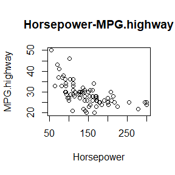

```r
attach(Cars93)
plot(x=Horsepower, y=MPG.highway, main = "Horsepower-MPG.highway")
```

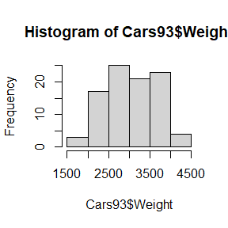

```r
hist(Cars93$Weight)
```

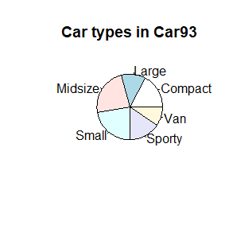

```r
pie(table(Cars93$Type),main = "Car types in Car93")
```

# A-22036-2022-09-16

## 3.3

### ANSWER

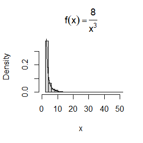

```r
n <- 1000
set.seed(0)
u <- runif(n)
x <- 2/ sqrt(1-u) # F(x) = 1- (2/x)^2, 2<=x
hist(x, prob = TRUE, main = expression(f(x)==frac(8,x^3)), breaks = 100, xlim=c(0,50))
y <- seq(2, 50, .01)
lines(y, 8/(y^3))
```

# 3.7

### QUESTION

Write a function to generate a random sample of size n from the Beta($a$, $b$) distribution by the acceptance-rejection method. Generate a random sample of size 1000 from the Beta(3, 2) distribution. Graph the histogram of the sample with the theoretical Beta(3, 2) density superimposed.

### ANSWER

```r
n <- 1e3;j<-k<-0;y <- numeric(n)
ar_beta <- function(a,b){
  while (k < n) {
    u <- runif(1)
    j <- j + 1
    x <- runif(1) #random variate from g().
    if (x^(a-1) * (1-x)^(b-1) > u) {
      #we accept x
      k <- k + 1
      y[k] <- x
    }
  }
  return (list(j,y))
}
```

```r
ans <- ar_beta(3,2)
ans[[1]]/n# value of c
```

```
## [1] 11.644
```

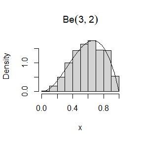

```r
x <- seq(0,1,0.01)

hist(ans[[2]], prob=T,main = expression(Be(3,2)), xlim=c(0,1), xlab="x")

lines(x, 12*x^2*(1-x))
```

## 3.12

### QUESTION

Simulate a continuous Exponential-Gamma mixture. Suppose that the rate parameter $\Lambda$ has Gamma($r$, $\beta$) distribution and $Y$ has Exp($\Lambda$) distribution. That is, $(Y|\Lambda = \lambda) \sim f_Y(y|\lambda) = \lambda e^{−\lambda y}$. Generate 1000 random observations from this mixture with $r$ = 4 and $β$ = 2.

### ANSWER

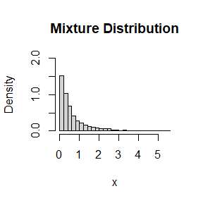

```r
n <- 1000; r <- 4; beta <- 2
lambda <- rgamma(n, r, beta)
x <- rexp(n, lambda) # the length of lambda = n
hist(x, prob = TRUE, breaks = 20, main = "Mixture Distribution", ylim = c(0,2))
```

## 3.13

### QUESTION

It can be shown that the mixture in Exercise 3.12 has a Pareto distribution with cdf
$$F(y) = 1 −
(\frac{\beta}{\beta + y}) ^ r, y ≥ 0.$$
(This is an alternative parameterization of the Pareto cdf given in Exercise 3.3.) Generate 1000 random observations from the mixture with $r$ = 4 and $\beta$ = 2. Compare the empirical and theoretical (Pareto) distributions by graphing the density histogram of the sample and superimposing the Pareto density curve.

### ANSWER

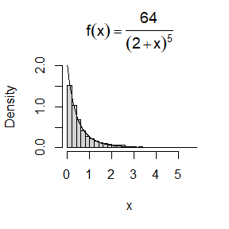

```r
hist(x, prob = TRUE, breaks = 20, main = expression(f(x)==frac(64,(2+x)^5)), ylim = c(0,2))
y <- seq(0, 50, .01)
lines(y, 64/(2+y)^5 )
```

# A-22036-2022-09-23

## Quicksort

### Question

1. For $n = 10^4, 2 × 10^4, 4 × 10^4, 6 × 10^4, 8 × 10^4$, apply the fast sorting algorithm to randomly permuted, numbers of $1, . . . , n$.
2. Calculate computation time averaged over 100 simulations, denoted by $a_n$.
3. Regress $a_n$ on $t_n := n log(n)$, and graphically show the results (scatter plot and regression line).

### Answer

```r
quick_sort <- function(x){
  num<-length(x)
  if (num==0||num==1){
    return(x)
  }
  else{
    a<-x[1]
    y<-x[-1]
    lower <- y[y<a]
    upper <-y [y>=a]
    return(c(quick_sort(lower),a,quick_sort(upper)))
  }
}
```

```r
e <- c(10^4, 2 * 10^4, 4 * 10^4, 6 * 10^4, 8 * 10^4)
a <- numeric(5)
t <- e*log(e)
for (i in 1:5){
  sum_t <- 0
  j <- 1
  for (j in 1:100){
    test <- sample(e[i])
    sum_t <- sum_t + system.time(quick_sort(test))[1]
    #system.time(quick_sort(test))[1]
  }
  a[i] <- sum_t/100
}
```

```r
fit <- lm(a~t)
summary(fit)
```

```
##
## Call:
## lm(formula = a ~ t)
##
## Residuals:
##         1         2         3         4         5
## -0.004818 -0.003432  0.009814  0.006680 -0.008245
##
## Coefficients:
##              Estimate Std. Error t value Pr(>|t|)
## (Intercept) 1.273e-02  7.379e-03   1.725   0.1830
## t           1.606e-07  1.357e-08  11.833   0.0013 **
## ---
## Signif. codes:  0 '***' 0.001 '**' 0.01 '*' 0.05 '.' 0.1 ' ' 1
##
## Residual standard error: 0.009017 on 3 degrees of freedom
## Multiple R-squared:  0.979,  Adjusted R-squared:  0.972
## F-statistic:   140 on 1 and 3 DF,  p-value: 0.001298
```

```r
fit$coef
```

```
##  (Intercept)            t
## 1.273010e-02 1.605594e-07
```

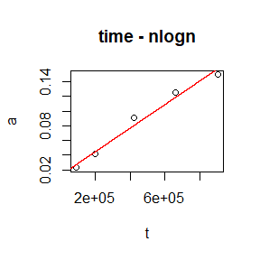

```r
plot(x=t,y=a,main = "time - nlogn")
y <- seq(0,10^6,1)
lines(y,fit$coef[1]+fit$coef[2]*y,col="red")
```

From the graph there is a linear relationship between time and $nlog(n)$. In fact it can be proved $time = O(nlogn)$.

## 5.6 & 5.7

### Answer

```r
MC.Phi <- function(R = 10000, antithetic = FALSE) {
  u <- runif(R/2)
  if (antithetic) v <- 1 - u else v <- runif(R/2)
  u <- c(u, v)
  g <- exp(u) # x*u ~ N(0,x)
  cdf <- mean(g)
  cdf
}
```

```r
m <- 1000
MC1 <- MC2 <- numeric(m)
x <- 1
for (i in 1:m) {
  MC1[i] <- MC.Phi(R = 1000, antithetic = FALSE)
  MC2[i] <- MC.Phi(R = 1000, antithetic = TRUE)
}
c(mean(MC1),mean(MC2))
```

```
## [1] 1.718060 1.718153
```

```r
#theta估计：MC方法 对偶方法
c(sd(MC1)^2,sd(MC2)^2,sd(MC2)^2/sd(MC1)^2)
```

```
## [1] 2.444883e-04 7.910555e-06 3.235556e-02
```

```r
#MC方法 对偶方法 对偶方法方差/MC方法方差
```

97% percent reduction in variance of $\hat{\theta}$ that can be achieved using antithetic variate, compared with simple MC.

$Cov(e^{U},e^{1-U})=E(e^{U}e^{1-U})-E(e^{U})E(e^{1-U})=e-(e-1)^2$ $Var(e^{U}+e^{1-U})=Var(e^{U})+Var(e^{1-U})+2Cov(e^{U},e^{1-U})=2[\frac{e^2-1}{2}-(e-1)^2]+2[e-(e-1)^2]=0.015$

$Var(\hat{\theta_{antithetic}})=\frac{Var(e^{U}+e^{1-U})}{2m}=\frac{0.015}{2000}= 7.5e-06$ $Var(\hat{\theta_{MC}}) =\frac{Var(e^{U)}}{m}=\frac{0.242}{1000}=2.42e-04$ $==0.03099174 $ Here the mathematical result agrees with experimental comparison.

# A-22036-2022-09-30

## 5.13

### Question1

Find two importance functions $f_1$ and $f_2$ that are supported on $(1, \infty)$ and are ‘close’ to
$$g(x) = \frac{x^2}{\sqrt{2\pi}} e^{−x^2/2}, x
> 1.$$

Which of your two importance functions should produce the smaller variance in estimating
$$\int^{\infty}_1
\frac{x^2}{\sqrt{2\pi}} e^{−x^2/2} dx$$

by importance sampling? Explain.

### Answer1

$g(x)=\frac{x^2}{\sqrt{2\pi}}e^{-\frac{1}{2}x^2}$ Let $f_1(x)=e^{1-x}, f_2(x)=\frac{1}{x^2}$

```r
pi <- 3.1415926
g <- function(x){
  return (x^2/sqrt(2*pi)*exp(-0.5*x^2))
}
f1 <- function(x){
  return (exp(1-x))
}
f2 <- function(x){
  return (1/(x^2))
  #return (1/sqrt(2*pi)*exp(-0.5*x^2))
}
m <- 1000
set.seed(123)
u <- runif(m)
x1 <- 1-log(1-u) # Inverse transform algorithm
x2 <- 1/(1-u) # Inverse transform algorithm
fg1 <- g(x1) / f1(x1)
fg2 <- g(x2) / f2(x2)
theta <- integrate(g,1,Inf)
theta1_hat <- mean(fg1)
theta2_hat <- mean(fg2)
sd1 <- sd(fg1)
sd2 <- sd(fg2)
c(theta[[1]], theta1_hat, theta2_hat) #(theta_true, theta_estimate_of_f1, theta_estimate_of_f2)
```

```
## [1] 0.4006260 0.4023681 0.4030237
```

```r
c(sd1,sd2) #(stand error with f1, stand error with f2)
```

```
## [1] 0.1559490 0.3050777
```

Estimate of method with $f_1$ and $f_1$ are both correct. Variance of the method with $f_1$ is smaller.

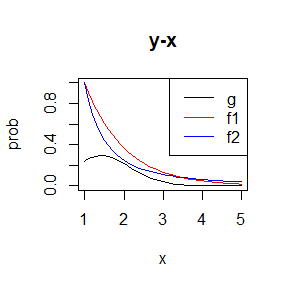

```r
x <- seq(1,5,0.1)
plot(x,g(x),type="l",ylim=c(0,1),ylab="prob",main="y-x")
lines(x,f1(x),col="red")
lines(x,f2(x),col="blue")
legend("topright",col=c("black","red","blue"),lty=1,legend=c("g","f1","f2"))
```

From the plot it can be seen in most areas, $f_1(x)$ is closer to have a shape of $cg(x)$ than $f_2(x)$, therefore its variance is smaller.

## 5.15

### Question2

Obtain the stratified importance sampling estimate in Example 5.13 and compare it with the result of Example 5.10.

There is something wrong with the subintervals in Exercise 5.15 (Example 5.13). You may modify it without losing the original intent.

### Answer2

```r
m <- 10000
N <- 50
k <- numeric(5)
theta_s <- numeric(5)
theta <- numeric(N)
var_s <- numeric(5)

set.seed(123)
g <- function(x) {
  exp(-x - log(1+x^2))
}
ab <- c(0,1/5,2/5,3/5,4/5,1)
for (i in 1:5)
  k[i] <- (1-exp(-1)) / (exp(-ab[i]) - exp(-ab[i+1]))


for (j in 1:N){
  for (i in 1:5){
    u <- runif(m)
    x <- -log(exp(-ab[i]) - u * (exp(-ab[i]) - exp(-ab[i+1])))
    tmpfg <- g(x) / (exp(-x) / (exp(-ab[i]) - exp(-ab[i+1])) )
    theta_s[i] <- mean(tmpfg)
    #var_s[i] <- sd(tmpfg)^2
  }
  theta[j] <- sum(theta_s)
}
mean(theta)
```

```
## [1] 0.524814
```

```r
var(theta)
```

```
## [1] 7.196569e-09
```

```r
c(0.5257801,0.0970314^2) #Estimate and variance from Example 5.13.
```

```
## [1] 0.525780100 0.009415093
```

It is clear that $Var(\hat\theta^{SI}) < Var(\hat\theta^I)$.

# A-22036-2022-10-09

## 6.4

### QUESTION

Suppose that $X_1,...,X_n$ are a random sample from a from a lognormal distribution with unknown parameters. Construct a 95% confidence interval for the parameter $\mu$. Use a Monte Carlo method to obtain an empirical estimate of the confidence level.

### ANSWER

#### stats analysis

X is from a log-normal distribution. Let $Y=Log(X) \sim N(\mu,\sigma^2)$. 95% CI of Y is $[L,R]=[\hat\beta-\frac{1}{\sqrt{n}}t_{n-1}(0.975)\hat\sigma,\hat\beta+\frac{1}{\sqrt{n}}t_{n-1}(0.975)\hat\sigma]$.Here $\hat\beta=mean(Y),\hat\sigma=sd(Y)$ So 95% CI of X is $[e^L,e^R]$.

#### data generating

```r
mcci <- function(m,n,miu, se){
  lower <- numeric(m)
  upper <- numeric(m)
  for (i in 1:m){
    Lx <- rnorm(n,miu,se)
    lower[i] <- mean(Lx) - qt(0.975, n-1)*sd(Lx)/sqrt(n)
    upper[i] <- mean(Lx) + qt(0.975, n-1)*sd(Lx)/sqrt(n)
  }
  L <- exp(mean(lower))
  R <- exp(mean(upper))
  rm(Lx) #clearing
  rm(upper)
  rm(lower)
  return (c(L, R))
}
```

#### result report

Example:

```r
mcci(1000,20,0,1)
```

```
## [1] 0.6285733 1.5858913
```

## 6.8

### QUESTION

Refer to Example 6.16. Repeat the simulation, but also compute the F test of equal variance, at significance level $\hat\alpha = 0.055$. Compare the power of the Count Five test and F test for small, medium, and large sample sizes. (Recall that the F test is not applicable for non-normal distributions.)

### ANSWER

#### data generating

```r
count5test <- function(x, y) {
X <- x - mean(x)
Y <- y - mean(y)
outx <- sum(X > max(Y)) + sum(X < min(Y))
outy <- sum(Y > max(X)) + sum(Y < min(X))
rm(X)
rm(Y)
return(as.integer(max(c(outx, outy)) > 5))
}
Ftest <- function(x,y){
  return (as.integer(var.test(x,y,alternative = "two.sided",conf.level = 0.945)[[3]]<0.055))
}
```

#### data analysis

```r
sigma1 <- 1
sigma2 <- 1.5
comparision <- function(m,n){
  num1 = num2 =0
  for (i in 1:m){
    x <- rnorm(n, 0, sigma1)
    y <- rnorm(n, 0, sigma2)
    num1 = num1 + count5test(x, y)
  }
  for (i in 1:m){
    x <- rnorm(n, 0, sigma1)
    y <- rnorm(n, 0, sigma2)
    num2 = num2 + Ftest(x, y)
  }
power1 <- num1/m
power2 <- num2/m
rm(x) #clear memory
rm(y) #clear memory
return (c(power1,power2))
}
```

#### result report

```r
print("CountFive Test, F Test")
```

```
## [1] "CountFive Test, F Test"
```

```r
comparision(1000,20) #small sample size
```

```
## [1] 0.333 0.445
```

```r
comparision(1000,200) #medium sample size
```

```
## [1] 0.939 1.000
```

```r
comparision(1000,2000) #large sample size
```

```
## [1] 0.999 1.000
```

When sample size is small, sample is not near normal distribution, so power of test is small. As sample size grows larger, power becomes larger too, approaching 1. Because CountFive test is a simple non-parametric test, its power is apparently lower than power of F test, for we operate test under normal distribution sample.

## Discussion

### QUESTION1

If we obtain the powers for two methods under a particular simulation setting with 10,000 experiments: say, 0.651 for one method and 0.676 for another method. Can we say the powers are different at 0.05 level?

### ANSWER1

See the analysis below. It depends on certain hypothesis test.

### QUESTION2

What is the corresponding hypothesis test problem?

### ANSWER2

Let $Power_1=$ power of first test, with estimate = 0.651, $Power_2=$ power of first test, with estimate = 0.676, $H_0:Power_1=Power_2,H1:Power1\neq Power2$.

### QUESTION3

Which test can we use? Z-test, two-sample t-test, paired-t test or McNemar test? Why?

### ANSWER3

McNemar test. McNemar is a non-parametric method for 10000 paired data, which is a 0-1 contingency table corresponding test (its content is a binomial distribution), while other three tests demand normal distribution, which is not suitable here. The problem can be written as a contingency table test, according to definition of power:

```r
t <- matrix(c("n11","n21","n12","n22"),2,2)
colnames(t) <- c("reject under H1", "accept under H1")
rownames(t) <- c("reject under H1", "accept under H1")
t
```

```
##                 reject under H1 accept under H1
## reject under H1 "n11"           "n12"
## accept under H1 "n21"           "n22"
```

Here row means test1 and column means test2.

Therefore:$H_0:n_{11}+n_{12}=n_{21}+n_{22}$. The statistic of test is $X = \frac{(n_{12}-n_{21})^2}{n_{12}+n_{21}}$ , and it is a Chi-Squared Distribution with $df=1$ under $H_0$.

### QUESTION4

Please provide the least necessary information for hypothesis testing.

### ANSWER4

From the problem description, we do not know the exact condition of each pair sample, but only know the total numbers. So we cannot provide the contingency table. Thus we cannot say the powers are different at 0.05 level. (Back to question1)

# A-22036-2022-10-14

```r
library(boot)
```

## 7.4

Refer to the air-conditioning data set aircondition provided in the boot package. The 12 observations are the times in hours between failures of air-conditioning equipment [63, Example 1.1]: 3, 5, 7, 18, 43, 85, 91, 98, 100, 130, 230, 487. Assume that the times between failures follow an exponential model $Exp(\lambda)$. Obtain the MLE of the hazard rate $\lambda$ and use bootstrap to estimate the bias and standard error of the estimate.

### ANSWER

#### stats analysis

Assume $X_1,X_2,...,X_n$ from $Exp(\lambda)$. Its pdf is $f(x,\lambda)=\lambda e^{-\lambda x}$. Likelihood $L(\lambda;x_1,...,x_n)=\lambda ^n e^{-n \overline{x} \lambda}$. $\frac{\partial L}{\partial{\lambda}}=n\lambda^{n-1}e^{-n \overline{x} \lambda}-n \overline{x} \lambda^{n-1}e^{-n \overline{x}}$. Let it = 0, here we can get MLE of $\lambda$ that $\hat\lambda = \frac{1}{\overline{X}}$.

#### data generating

```r
x <- c(3, 5, 7, 18, 43, 85, 91, 98, 100, 130, 230, 487)
B <- 1e4
set.seed(1)
thetastar <- numeric(B)
theta <- mean(x)
for(b in 1:B){
  xstar <- sample(x,replace=TRUE)
  thetastar[b] <- mean(xstar)
}
```

#### result report

```r
c(thetahat= mean(thetastar), theta= theta)
```

```
## thetahat    theta
## 107.6954 108.0833
```

```r
c(bias=mean(thetastar)-theta, se.boot=sd(thetastar), se.samp=sd(x)/sqrt(length(x)))
```

```
##       bias    se.boot    se.samp
## -0.3879167 37.5637674 39.3268083
```

```r
rm(thetastar)
```

## 7.5

### QUESTION

Refer to Exercise 7.4. Compute 95% bootstrap confidence intervals for the mean time between failures $\frac{1}{\lambda}$ by the standard normal, basic, percentile, and BCa methods. Compare the intervals and explain why they may differ.

### ANSWER

#### stats analysis

$\hat {\frac{1}{\lambda}}= \overline X$.

#### data generating

```r
mu <- 1
b <- 1
n <- 1e1
m <- 1e3

set.seed(12345)

boot.median <- function(t,i){
  return (median(t[i]))
}
boot.mean <- function(t,i){
  return (mean(t[i]))
}

ci.norm <- ci.basic <- ci.perc <- ci.bca <- matrix(NA,m,2)
de <- boot(data=x,statistic=boot.median, R = 999)
ci <- boot.ci(de,type=c("norm","basic","perc","bca"), conf=0.95)
print(ci)
```

```
## BOOTSTRAP CONFIDENCE INTERVAL CALCULATIONS
## Based on 999 bootstrap replicates
##
## CALL :
## boot.ci(boot.out = de, conf = 0.95, type = c("norm", "basic",
##     "perc", "bca"))
##
## Intervals :
## Level      Normal              Basic
## 95%   ( 39.74, 158.19 )   ( 61.00, 163.50 )
##
## Level     Percentile            BCa
## 95%   ( 12.50, 115.00 )   (  7.00, 112.56 )
## Calculations and Intervals on Original Scale
```

#### result report & analysis

In fact $\overline X$ is with a distribution of $Gamma(n,n \lambda)$. A rough representation of distribution of $\overline X$ is here:

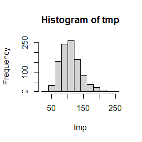

```r
tmp <- rgamma(1000,shape = 12, scale = 1/12*108)
hist(tmp)
```

```r
rm(tmp)
```

## Project A

### QUESTION

Conduct a Monte Carlo study to estimate the coverage probabilities of the standard normal bootstrap confidence interval, the basic bootstrap confidence interval, and the percentile confidence interval. Sample from a normal population and check the empirical coverage rates for the sample mean. Find the proportion of times that the confidence intervals miss on the left, and the proportion of times that the confidence intervals miss on the right.

```r
bootci_mc <- function(mu, sigma, n = 10, m = 10000){
  ci.norm <- ci.basic <- ci.perc <- matrix(NA, m, 2)
  prob.c <- prob.l <- prob.r <- c(0, 0, 0)
  for(i in 1:m){
    s <- rnorm(n, mu, sigma)
    de <- boot(data = s, statistic = boot.median, R = 999)
    ci <- boot.ci(boot.out = de, type = c("norm", "basic", "perc"))
    ci.norm[i, ] <- ci$norm[2:3];ci.basic[i, ] <- ci$basic[4:5];ci.perc[i, ] <- ci$percent[4:5]

    #ms <- mean(s)
    #print(ms)
    #if (ci.norm[, 1] <= ms & ci.norm[, 2] >= ms) prob.c[1] <- prob.c[1] +1
    #if (ci.basic[, 1] <= ms & ci.basic[, 2] >= ms) prob.c[2] <- prob.c[2] +1
    #if (ci.perc[, 1] <= ms & ci.perc[, 2] >= ms) prob.c[3] <- prob.c[3] +1

    #if (ci.norm[, 2] <= ms) prob.l[1] <- prob.l[1] +1
    #if (ci.basic[, 2] <= ms) prob.l[2] <- prob.l[2] +1
    #if (ci.perc[, 2] <= ms) prob.l[3] <- prob.l[3] +1

    #if (ci.norm[, 1] >= ms) prob.r[1] <- prob.r[1] +1
    #if (ci.basic[, 1] >= ms) prob.r[2] <- prob.r[2] +1
    #if (ci.perc[, 1] >= ms) prob.r[3] <- prob.r[3] +1
  }
  rm(s)
  rm(de)
  return(rbind(c(mean(ci.norm[, 1] <= mu & ci.norm[, 2] >= mu), mean(ci.norm[, 2] <= mu), mean(ci.norm[, 1] >= mu)),
               c(mean(ci.basic[, 1] <= mu & ci.basic[, 2] >= mu), mean(ci.basic[, 2] <= mu), mean(ci.basic[, 1] >= mu)),
               c(mean(ci.perc[, 1] <= mu & ci.perc[, 2] >= mu), mean(ci.perc[, 2] <= mu), mean(ci.perc[, 1] >= mu))))
  #return (c(prob.c, prob.l, prob.r))
}
```

#### result report

```r
ci <- bootci_mc(mu = 0, sigma = 1, n = 50, m = 1000)
rownames(ci) <- c("normal", "basic", "perc")
colnames(ci) <- c("coverage.prob", "missed.left", "missed.right")
```

The table below shows the empirical coverage rates for the sample mean, and the proportion of times that the confidence intervals miss on the left/right.

```r
ci
```

```
##        coverage.prob missed.left missed.right
## normal         0.925       0.037        0.038
## basic          0.877       0.062        0.061
## perc           0.950       0.028        0.022
```

Compared with mean, (not sample mean, because there will be full coverage than), bootstrap-percentile covers best.

# A-22036-2022-10-21

## 7.8

### QUESTION

Refer to Exercise 7.7. Obtain the jackknife estimates of bias and standard error of $\hat\theta$

### ANSWER

#### data generating

```r
library(bootstrap)
data <- bootstrap::scor
```

```r
sigma_hat <- cov(data)
theta_hat <- eigen(sigma_hat)$values[1] / sum(eigen(sigma_hat)$values)
```

```r
n <- nrow(data)
theta_jack <- numeric(n)
for (i in 1:n){
  tmp_scor <- cov(data[-i,])
  e <- eigen(tmp_scor)
  theta_jack[i] <- e$values[1] / sum(e$values)
}
```

```r
rm(data)
rm(tmp_scor)
```

#### result report

```r
sigma_hat
```

```
##          mec       vec       alg       ana       sta
## mec 305.7680 127.22257 101.57941 106.27273 117.40491
## vec 127.2226 172.84222  85.15726  94.67294  99.01202
## alg 101.5794  85.15726 112.88597 112.11338 121.87056
## ana 106.2727  94.67294 112.11338 220.38036 155.53553
## sta 117.4049  99.01202 121.87056 155.53553 297.75536
```

```r
theta_hat
```

```
## [1] 0.619115
```

```r
bias <- (n-1) * (mean(theta_jack) - theta_hat)
se_theta <- sqrt((n-1) * mean((theta_jack - mean(theta_jack))^2))
c(bias,se_theta)
```

```
## [1] 0.001069139 0.049552307
```

## 7.11

### QUESTION

In Example 7.18, leave-one-out (n-fold) cross validation was used to select the best fitting model. Use leave-two-out cross validation to compare the models.

### ANSWER

#### data generating

```r
library(DAAG)
attach(ironslag)
```

```r
n <- length(magnetic) #in DAAG ironslag
e1 <- e2 <- e3 <- e4 <- numeric(n*(n-1)/2)

i <- 0
for (k in 1:(n-1)) {
  for (j in (k+1):n){
    #if (k==j) break
    y <- magnetic[-c(k,j)]
    x <- chemical[-c(k,j)]

    J1 <- lm(y ~ x)
    yhat1k <- J1$coef[1] + J1$coef[2] * chemical[k]
    yhat1j <- J1$coef[1] + J1$coef[2] * chemical[j]
    e1[i] <- ((magnetic[k] - yhat1k)^2 + (magnetic[j] - yhat1j)^2)/2

    J2 <- lm(y ~ x+ I(x^2))
    yhat2k <- J2$coef[1] + J2$coef[2] * chemical[k] + J2$coef[3] * chemical[k]^2
    yhat2j <- J2$coef[1] + J2$coef[2] * chemical[j] + J2$coef[3] * chemical[j]^2
    e2[i] <- ((magnetic[k] - yhat2k)^2 + (magnetic[j] - yhat2j)^2)/2

    J3 <- lm(log(y) ~ x)
    yhat3k <- exp(J3$coef[1] + J3$coef[2] * chemical[k])
    yhat3j <- exp(J3$coef[1] + J3$coef[2] * chemical[j])
    e3[i] <- ((magnetic[k] - yhat3k)^2 + (magnetic[j] - yhat3j)^2)/2

    J4 <- lm(log(y) ~ log(x))
    yhat4k <- exp(J4$coef[1] + J4$coef[2] * log(chemical[k]))
    yhat4j <- exp(J4$coef[1] + J4$coef[2] * log(chemical[j]))
    e4[i] <- ((magnetic[k] - yhat4k)^2 + (magnetic[j] - yhat4j)^2)/2

    i <- i+1
  }
}
```

#### result report

```r
c(mean(e1), mean(e2), mean(e3), mean(e4))
```

```
## [1] 19.55727 17.85409 18.43866 20.45229
```

```r
rm(e1,e2,e3,e4,yhat1j,yhat1k,yhat2k,yhat2j,yhat3k,yhat3j,yhat4k,yhat4j)
```

Here model 2 is the best, with the least prediction error.

## 8.2

### QUESTION

Implement the bivariate Spearman rank correlation test for independence as a permutation test. The Spearman rank correlation test statistic can be obtained from function cor with method = “spearman”. Compare the achieved significance level of the permutation test with the p-value reported by cor.test on the same samples.

### ANSWER

#### data generating

Generate two groups of data : x,y .

```r
set.seed(123456)
x <- 1:10
y <- c(sort(rnorm(5)),sort(rnorm(5)))
cor_hat <- cor(x,y,method = "spearman")
p_cor.test <- cor.test(x,y, method = "spearman")[[3]]
```

#### data analysis

Compute p-value through permutation test.

```r
m <- 2000
cor_t <- numeric(m)
for (i in 1:m){
  z <- sample(c(x,y))
  cor_t[i] <- cor(z[1:10],z[11:20],method = "spearman")
}
p_permutation <- mean(abs(cor_t)>=abs(cor_hat))
c(p_permutation, p_cor.test)
```

```
## [1] 0.02650000 0.02751412
```

```r
rm(x,y,cor_t)
```

P-value from permutation method is close to p-value from cor.test function.

# A-22036-2022-10-28

## 9.4

### QUESTION

Implement a random walk Metropolis sampler for generating the standard Laplace distribution (see Exercise 3.2). For the increment, simulate from a normal distribution. Compare the chains generated when different variances are used for the proposal distribution. Also, compute the acceptance rates of each chain.

### ANSWER

#### MCMC gennerating using random walk metropolis

$\alpha(x_t, y)=min(1,\frac{f(y)}{f(x_t)})=min(1,e^{-\lvert{y}\rvert+ \lvert{x}\rvert})$

```r
rw.Metropolis <- function(sigma, x0, N){
  x <- numeric(N)
  x[1] <- x0
  u <- runif(N)
  k <- 0
  for (i in 2:N){
    y <- rnorm(1,x[i-1],sigma)
    if (u[i] <= exp(-abs(y)+abs(x[i-1])))
      x[i] <- y
    else{x[i] <- x[i-1]; k <- k+1}
  }
  return (list(x=x,k=k))
}

Gelman.Rubin <- function(psi){
  psi <- as.matrix(psi)
  n <- ncol(psi)
  k <- nrow(psi)
  psi.means <- rowMeans(psi)
  B <- n * var(psi.means)
  psi.w <- apply(psi,1,"var")
  W <- mean(psi.w)*(n-1)/n
  v.hat <- W * (n-1)/n + (B/(n))
  r.hat <- v.hat / W
  return (r.hat)
}
```

#### result report

```r
N <- 2000
sigma <- c(0.05, 0.5, 1, 5)
x0 <- 5
rw1 <- rw.Metropolis(sigma[1], x0, N)
rw2 <- rw.Metropolis(sigma[2], x0, N)
rw3 <- rw.Metropolis(sigma[3], x0, N)
rw4 <- rw.Metropolis(sigma[4], x0, N)
reject_rate <- c(rw1$k, rw2$k ,rw3$k, rw4$k)/N
reject_rate
```

```
## [1] 0.0165 0.1730 0.3120 0.7230
```

```r
#par(mfrow=c(2,2))
plot(rw1$x,type="l",xlab="sigma=0.05",ylab="X",ylim=range(rw1$x))
plot(rw2$x,type="l",xlab="sigma=0.5",ylab="X",ylim=range(rw2$x))
plot(rw3$x,type="l",xlab="sigma=1",ylab="X",ylim=range(rw3$x))
plot(rw4$x,type="l",xlab="sigma=5",ylab="X",ylim=range(rw4$x))
```

[output not shown]

When sigma is too small, mc list cannot converge in first 2000 turns. As variance increases, reject rate increases as well, that is, speed of convergence grows. However, when sigma is too big, the list may not be more effective.

```r
GR.converge <- function(sigma, k = 10, m = 5000){
  n.converge <- numeric(4)
    x0 <- rnorm(k, 0, 5)
    psi <- data.frame()
    for(j in 1:k)
      psi <- rbind(psi, rw.Metropolis(sigma, x0[j],  m)$x)

    for(n in 2:m){
      GR <- Gelman.Rubin(as.matrix(psi)[, 1:n])
      if(GR < 1.2)
        break
    }
  return (n)
}
```

#### use Gelman Rubin to compute iteration until convergence.

```r
set.seed(1)
cat("sigma=0.5:",GR.converge(sigma[2]),"\n")
```

```
## sigma=0.5: 608
```

```r
cat("sigma=1:",GR.converge(sigma[3]),"\n")
```

```
## sigma=1: 58
```

```r
cat("sigma=5:",GR.converge(sigma[4]),"\n")
```

```
## sigma=5: 49
```

```r
rm(rw1,rw2,rw3,rw4)
```

## 9.7

### QUESTION

Implement a Gibbs sampler to generate a bivariate normal chain $(X_t, Y_t)$ with zero means, unit standard deviations, and correlation 0.9. Plot the generated sample after discarding a suitable burn-in sample. Fit a simple linear regression model $Y = β_0 + β_1X$ to the sample and check the residuals of the model for normality and constant variance.

### ANSWER

#### mcmc generating

```r
gibbs <- function(x01, x02, N = 5000){

burn <- 1000 # burn-in length
X <- matrix(0, N, 2) # the chain, a bivariate sample

rho <- 0.9
mu1 <- 0
mu2 <- 0
sigma1 <- 1
sigma2 <- 1
s1 <- sqrt(1-rho^2)*sigma1
s2 <- sqrt(1-rho^2)*sigma2

X[1, ] <- c(x01, x02)
for (i in 2:N) {
  x2 <- X[i-1, 2]
  m1 <- mu1 + rho * (x2 - mu2) * sigma1/sigma2
  X[i, 1] <- rnorm(1, m1, s1)
  x1 <- X[i, 1]
  m2 <- mu2 + rho * (x1 - mu1) * sigma2/sigma1
  X[i, 2] <- rnorm(1, m2, s2)
}

b <- burn + 1
x <- X[b:N, ]
return (X)
}
```

#### result report

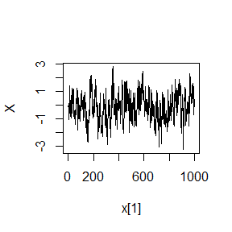

```r
burn <- 1000
x <- gibbs(0,0)[(burn+1):N,]
plot(x[,1],type="l",xlab="x[1]",ylab="X",ylim=range(x[,1]))
```

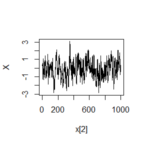

```r
plot(x[,2],type="l",xlab="x[2]",ylab="X",ylim=range(x[,2]))
```

```r
colMeans(x)
```

```
## [1] -0.1144960 -0.1112776
```

```r
cov(x)
```

```
##           [,1]      [,2]
## [1,] 0.9698688 0.8611772
## [2,] 0.8611772 0.9560940
```

```r
cor(x)
```

```
##           [,1]      [,2]
## [1,] 1.0000000 0.8943052
## [2,] 0.8943052 1.0000000
```

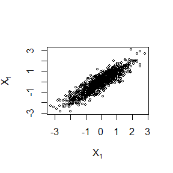

```r
plot(x, main="", cex=.5, xlab = bquote(X[1]), ylab = bquote(X[1]), ylim=range(x[,2]))
```

#### lm test

```r
fit <- lm(x[,2]~x[,1])
summary(fit)
```

```
##
## Call:
## lm(formula = x[, 2] ~ x[, 1])
##
## Residuals:
##      Min       1Q   Median       3Q      Max
## -1.50122 -0.29313  0.00604  0.28450  1.43153
##
## Coefficients:
##              Estimate Std. Error t value Pr(>|t|)
## (Intercept) -0.009613   0.013936   -0.69     0.49
## x[, 1]       0.887932   0.014063   63.14   <2e-16 ***
## ---
## Signif. codes:  0 '***' 0.001 '**' 0.01 '*' 0.05 '.' 0.1 ' ' 1
##
## Residual standard error: 0.4377 on 998 degrees of freedom
## Multiple R-squared:  0.7998, Adjusted R-squared:  0.7996
## F-statistic:  3987 on 1 and 998 DF,  p-value: < 2.2e-16
```

#### Gelman Rubin monotoring

```r
GR.biconverge <- function(m = 5000){
  k = 20
  x0 <- rnorm(k, 5, 5)
  psi1 <- psi2 <- data.frame()
  for(j in 1:k/2){
    xk <- gibbs(x0[j], x0[j+10],  m)
    psi1 <- rbind(psi1, xk[,1])
    psi2 <- rbind(psi2, xk[,2])
  }
  for(n in 10:m){
    GR1 <- Gelman.Rubin(as.matrix(psi1)[, 1:n])
    GR2 <- Gelman.Rubin(as.matrix(psi2)[, 1:n])
    #print(c(GR1,GR2))
    if(GR1 < 1.2 & GR2< 1.2)
      break
  }
  return (n)
}
```

When the mc chain converges through gr monitoring:

```r
GR.biconverge()
```

```
## [1] 27
```

```r
rm(x)
```

# A-22036-2022-11-04

## ANSWER1

### data generating

Key: Permutate X in first hypothesis, permutate Y in second hypothesis, permutate M in third hypothesis.

```r
generating <- function(alpha, beta, gamma, N){
  x <- rnorm(N)
  eM <- rnorm(N)
  eY <- rnorm(N)
  m <- alpha*x + eM
  y <- beta*m + gamma*x + eY
  return(data.frame(x, m, y))
}
```

```r
t_comp <- function(x, m, y){
  data <- data.frame(x, m, y)
  Model_M <- lm(m~x, data)
  Model_Y <- lm(y~m+x, data)
  t_stat <- Model_M$coef[2]*Model_Y$coef[2]/sqrt(Model_M$coef[2]^2*(summary(Model_M)$coefficients[2,2])^2+Model_Y$coef[2]^2*(summary(Model_Y)$coefficients[2,2])^2)
  return(as.numeric(t_stat))
}

permutation_1 <- function(data, N = 20, B = 99){
  reps <- numeric(B)
  for (i in 1:B) {
    k <- sample(1:N, size = N, replace = FALSE)
    x <- data[k, 1]
    reps[i] <- t_comp(x, data$m, data$y)
  }
  p <- (sum(abs(reps) > abs(t_comp(data$x, data$m, data$y)))+1)/(1+B)
  return (p)
}

permutation_2 <- function(data, N = 20, B = 99){
  reps <- numeric(B)
  for (i in 1:B) {
    k <- sample(1:N, size = N, replace = FALSE)
    y <- data[k, 3]
    reps[i] <- t_comp(data$x, data$m, y)
  }
  p <- (sum(abs(reps) > abs(t_comp(data$x, data$m, data$y)))+1)/(1+B)
  return (p)
}

permutation_3 <- function(data, N = 20, B = 99){
  reps <- numeric(B)
  for (i in 1:B) {
    k <- sample(1:N, size = N, replace = FALSE)
    m <- data[k, 2]
    reps[i] <- t_comp(data$x, m, data$y)
  }
  p <- (sum(abs(reps)>abs(t_comp(data$x, data$m, data$y)))+1)/(1+B)
  return (p)
}
```

### report

```r
func <- function(alpha, beta, gamma=1, N=20){
  K <- 100
  p <- matrix(0, nrow = 3, ncol = K)
  for (i in 1:K) {
    data <- generating(alpha, beta, gamma, N)
    p[1,i] <- permutation_1(data)
    p[2,i] <- permutation_2(data)
    p[3,i] <- permutation_3(data)
  }
  return(c(mean(p[1,]<=0.05),mean(p[2,]<=0.05),mean(p[3,]<=0.05)))
}
```

```r
set.seed(1)
simulation1 <- func(alpha=0, beta=0)
simulation2 <- func(alpha=0, beta=1)
simulation3 <- func(alpha=1, beta=0)
```

```r
Permutation_Test <- data.frame(Model1=simulation1, Model2=simulation2, Model3=simulation3)
row.names(Permutation_Test) <- c("Permutation_Test_1", "Permutation_Test_2", "Permutation_Test_3")
Permutation_Test
```

```
##                    Model1 Model2 Model3
## Permutation_Test_1   0.11   0.22   0.17
## Permutation_Test_2   0.33   1.00   0.02
## Permutation_Test_3   0.05   0.35   0.34
```

```r
#Type 1 error table
```

```r
rm(Permutation_Test)
```

## ANSWER2

### data generating

```r
set.seed(12345)

#N <- 1e6; b1 <- 1; b2 <- 0.5; f0 <- 0.01
work <- function(N=1e6, b1=1, b2=0.5, b3=1, f0=0.01){
x1 <- rpois(N,1); x2 <- rexp(N,1); x3 <- sample(0:1,N,replace=TRUE)
g <- function(alpha){
tmp <- exp(-alpha-b1*x1-b2*x2-b3*x3)
p <- 1/(1+tmp)
mean(p) - f0
}
solution <- uniroot(g,c(-20,0))
return (round(unlist(solution),5)[1:3])
}
```

### report

```r
work(1e6,0,1,-1,0.1)
```

```
##     root   f.root     iter
## -3.16674  0.00000 10.00000
```

```r
work(1e6,0,1,-1,0.01)
```

```
##     root   f.root     iter
## -6.06819  0.00000 10.00000
```

```r
work(1e6,0,1,-1,0.001)
```

```
##     root   f.root     iter
## -8.71014  0.00000 11.00000
```

```r
work(1e6,0,1,-1,0.0001)
```

```
##      root    f.root      iter
## -11.29142   0.00000  11.00000
```

```r
f00 <- c(0.1,0.01,0.001,0.0001)
x <- f00
for (i in 1:length(f00))
  x[i] <- work(1e6,0,1,-1,f00[i])
```

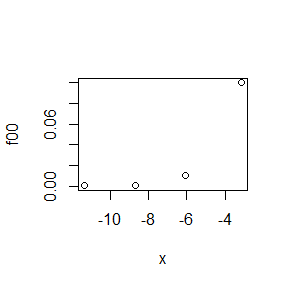

```r
plot(y=f00,x=x)
```

```r
rm(x,f00)
```

# A-22036-2022-11-11

### Answer 1

#### likelihood MLE

```r
u <- c(11,8,27,13,16,0,23,10,24,2)
v <- c(12,9,28,14,17,1,24,11,25,3)
n = length(u)
```

```r
L1 <- function(lam){

  t = 1
  t <- -sum(u) + sum( (v-u) / ( exp(lam*(v-u))-1 ))
  return (t)
}
```

```r
uniroot(L1,c(0,30))[1]
```

```
## $root
## [1] 0.07200052
```

#### EM algorithm

```r
iter <- 0
eps <- 1e-5
lambda_1 <- 1
lambda <- 2
while(1){
  lambda_1 <- lambda_1 - L1(lambda)/n
  if (abs(1/lambda_1 - lambda) < eps) break
  iter <- iter+1
  lambda <- 1/lambda_1
}
c(iter = iter, lambda = lambda)
```

```
##       iter     lambda
## 2.00000000 0.07197274
```

From the result we can see both estimates are 0.072, through simple MLE and EM iteration, which shows EM estimate equals to MLE.

```r
rm(u,v)
rm(lambda,lambda_1)
```

### 2.1.3

#### 4.

##### Question

Why do you need to use unlist() to convert a list to an atomic vector? Why doesn’t as.vector() work?

##### Answer

Elements in a vector have same type, while lists do not demand this. So “as.vector” will convert a vector with elements of same type, while “unlist” not.

### 2.3.1

#### 1.

##### Question

What does dim() return when applied to a vector?

##### Answer

NULL. “dim” is for matrix, array, or data frame.

```r
dim(c(1,2,3))
```

[output not shown]

### 2.4.5

#### 2.

##### Question

```r
t
```

[output not shown]

#### 3.

##### Question

Can you have a data frame with 0 rows? What about 0 columns?

##### Answer

There exist data frames in R with 0 rows, but no data frames with 0 columns (when it has only one column, it turns back to a vector).

# A-22036-2022-11-18

### Question1

The function below scales a vector so it falls in the range [0, 1]. How would you apply it to every column of a data frame? How would you apply it to every numeric column in a data frame?

### Answer1

```r
scale01 <- function(x) {
rng <- range(x, na.rm = TRUE)
(x - rng[1]) / (rng[2] - rng[1])
}
```

```r
data1 <- data.frame(x=c(1,2,3),y=c(4,5,6))
data1
```

```
##   x y
## 1 1 4
## 2 2 5
## 3 3 6
```

```r
lapply(data1, scale01)
```

```
## $x
## [1] 0.0 0.5 1.0
##
## $y
## [1] 0.0 0.5 1.0
```

```r
library(tidyverse)
data2 <- data.frame(x=c(1,2,3),y=c(4,5,6),z=c("a","b","c"))
lapply(select_if(data2,is.numeric), scale01)
```

```
## $x
## [1] 0.0 0.5 1.0
##
## $y
## [1] 0.0 0.5 1.0
```

### Question2

Use vapply() to: a) Compute the standard deviation of every column in a numeric data frame. b) Compute the standard deviation of every numeric column in a mixed data frame. (Hint: you’ll need to use vapply() twice.)

### Answer2

#### (a)

```r
vapply(data1, sd, FUN.VALUE = numeric(1))
```

```
## x y
## 1 1
```

#### (b)

```r
vapply( data2[,which(vapply(
  data2,is.numeric,FUN.VALUE = logical(1)))]
  , sd, FUN.VALUE = numeric(1))
```

```
## x y
## 1 1
```

```r
rm(data1,data2)
```

### Question3

Implement a Gibbs sampler to generate a bivariate normal chain (Xt, Yt) with zero means, unit standard deviations, and correlation 0.9. (a) Write an Rcpp function. (b) Compare the corresponding generated random numbers with pure R language using the function “qqplot”. (c) Compare the computation time of the two functions with the function “microbenchmark”.

### Answer3

```r
library(Rcpp)
library(microbenchmark)
```

#### (a)

```r
cppFunction('NumericMatrix gibbs(double x01, double x02, int N = 1000){

NumericMatrix x(N+1000, 2);

double rho = 0.9 ;
double mu1 = 0, mu2 = 0;
double sigma1 = 1, sigma2 = 1;
double s1 = sqrt(1-rho*rho)*sigma1 ;
double s2 = sqrt(1-rho*rho)*sigma2 ;

x(0,0) = x01, x(0,1) = x02;

for (int i=1; i<N+1000; i++) {
  double x2 = x(i-1,1);
  double m1 = mu1 + rho * (x2 - mu2) * sigma1/sigma2;
  x(i,0) = rnorm(1, m1, s1)[0];
  double x1 = x(i,0);
  double m2 = mu2 + rho * (x1 - mu1) * sigma2/sigma1;
  x(i,1) = rnorm(1, m2, s2)[0];
}

return (x);
}')
```

```r
gibbsR <- function(x01, x02, N = 2000){

burn <- 1000 # burn-in length
X <- matrix(0, N, 2) # the chain, a bivariate sample

rho <- 0.9
mu1 <- 0
mu2 <- 0
sigma1 <- 1
sigma2 <- 1
s1 <- sqrt(1-rho^2)*sigma1
s2 <- sqrt(1-rho^2)*sigma2

X[1, ] <- c(x01, x02)
for (i in 2:N) {
  x2 <- X[i-1, 2]
  m1 <- mu1 + rho * (x2 - mu2) * sigma1/sigma2
  X[i, 1] <- rnorm(1, m1, s1)
  x1 <- X[i, 1]
  m2 <- mu2 + rho * (x1 - mu1) * sigma2/sigma1
  X[i, 2] <- rnorm(1, m2, s2)
}

b <- burn + 1
x <- X[b:N, ]
return (x)
}
```

#### (b)

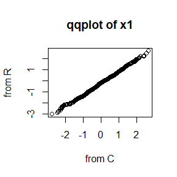

```r
x <- gibbs(100,10)[c(1001:2000),]
y <- gibbsR(100,10)
qqplot(x[,1], y[,1],main="qqplot of x1", xlab="from C", ylab="from R")
```

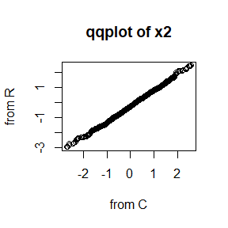

```r
qqplot(x[,2], y[,2],main="qqplot of x2", xlab="from C", ylab="from R")
```

From qqplot both generated random numbers corresponds the same distribution.

#### (c)

```r
ts <- microbenchmark(gibbR=gibbsR(100,10),
gibbC=gibbs(100,10))
summary(ts)[,c(1,3,5,6)]
```

```
##    expr       lq   median       uq
## 1 gibbR 5959.501 6532.051 8070.051
## 2 gibbC  447.751  455.051  466.201
```

Function from C is much quicker than that from R.

```r
rm(x,y)
```